# Отчет ТЗ №3

Никонов Максим 316 группа вариант 7

```
Зависимая переменная
Великобритания фунт/USD https://www.finam.ru/profile/forex/gbp-usd/
Предикторы
Индекс S&P500 https://www.finam.ru/profile/mirovye-indeksy/sandp-500/export/
Золото https://www.finam.ru/profile/tovary/gold/export/
Нефть.Брент https://www.finam.ru/profile/tovary/brent/export/
Швецария франк/ USD https://www.finam.ru/profile/forex/chf-usd/export/
Euro/USD https://www.finam.ru/profile/forex/eur-usd/export/
Платина https://www.finam.ru/profile/tovary/platinum/export/
Норвегия крона/USD https://www.finam.ru/profile/forex/usd-nok/export/
```

Использованные пакеты : library(dplyr) library(ISwR) library(corrplot) library(nortest)

Импорт сохраненных и уже видоизменненых файлов (оставлены только столбцы "DATE" и "CLOSE")

```r
nz <- read.csv2("/Users/Nikon/Desktop/CMC MSU/MC/6 sem/R/3/1.csv",sep = ';', header = TRUE, dec = ".")
pred1 <- read.csv2("/Users/Nikon/Desktop/CMC MSU/MC/6 sem/R/3/pred1.csv", sep = ';', header = TRUE, dec = ".")
pred2 <- read.csv2("/Users/Nikon/Desktop/CMC MSU/MC/6 sem/R/3/pred2.csv", sep = ';', header = TRUE, dec = ".")
pred3 <- read.csv2("/Users/Nikon/Desktop/CMC MSU/MC/6 sem/R/3/pred3.csv", sep = ';', header = TRUE, dec = ".")
pred4 <- read.csv2("/Users/Nikon/Desktop/CMC MSU/MC/6 sem/R/3/pred4.csv", sep = ';', header = TRUE, dec = ".")
pred5 <- read.csv2("/Users/Nikon/Desktop/CMC MSU/MC/6 sem/R/3/pred5.csv", sep = ';', header = TRUE, dec = ".")
pred6 <- read.csv2("/Users/Nikon/Desktop/CMC MSU/MC/6 sem/R/3/pred6.csv", sep = ';', header = TRUE, dec = ".")
pred7 <- read.csv2("/Users/Nikon/Desktop/CMC MSU/MC/6 sem/R/3/pred7.csv",sep = ';', header = TRUE, dec = ".")
```

Объединнеие разных баз данных в единную базу М и сохранизация их по слобцу "DATE"

```r
M <- merge(nz, pred1, by = "X.DATE.", incomparables = NA, sort = FALSE) %>%
  merge(pred2,by = "X.DATE.", incomparables = NA, sort = FALSE) %>%
  merge(pred3,by = "X.DATE.", incomparables = NA, sort = FALSE) %>%
  merge(pred4,by = "X.DATE.", incomparables = NA, sort = FALSE) %>%
  merge(pred5,by = "X.DATE.", incomparables = NA, sort = FALSE) %>%
  merge(pred6,by = "X.DATE.", incomparables = NA, sort = FALSE) %>%
  merge(pred7,by = "X.DATE.", incomparables = NA, sort = FALSE)
M
```

A data.frame: 486 × 9

| X.DATE. <chr> | X.CLOSE.F. <dbl> | X.CLOSE.INDEX. <dbl> | X.CLOSE.GOLD. <dbl> | X.CLOSE.OIL. <dbl> | X.CLOSE.FRANK. <dbl> | X.CLOSE.EURO. <dbl> | X.CLOSE.PLATINUM. <dbl> | X.CLOSE.CROWN. <dbl> |
| --- | --- | --- | --- | --- | --- | --- | --- | --- |
| 05.02.2019 | 1.2955 | 2737.70 | 1318.0 | 62.11 | 0.9999 | 1.14128 | 819.4 | 8.47681 |
| 06.02.2019 | 1.2936 | 2731.61 | 1307.8 | 62.55 | 0.9979 | 1.13682 | 807.0 | 8.53577 |
| 07.02.2019 | 1.2949 | 2706.05 | 1313.4 | 61.68 | 0.9976 | 1.13425 | 797.3 | 8.59329 |
| 08.02.2019 | 1.2935 | 2707.88 | 1318.2 | 61.97 | 0.9997 | 1.13221 | 802.4 | 8.63694 |
| 11.02.2019 | 1.2862 | 2709.80 | 1312.3 | 61.58 | 0.9954 | 1.12764 | 789.8 | 8.71929 |
| 12.02.2019 | 1.2895 | 2744.73 | 1316.8 | 62.61 | 0.9939 | 1.13315 | 792.9 | 8.64719 |
| 13.02.2019 | 1.2848 | 2753.03 | 1312.0 | 63.60 | 0.9908 | 1.12663 | 787.9 | 8.65850 |
| 14.02.2019 | 1.2792 | 2745.73 | 1315.3 | 64.56 | 0.9946 | 1.12915 | 785.8 | 8.64773 |
| 15.02.2019 | 1.2891 | 2775.60 | 1325.0 | 66.39 | 0.9950 | 1.12991 | 808.4 | 8.63040 |
| 19.02.2019 | 1.3066 | 2779.76 | 1345.5 | 66.44 | 0.9989 | 1.13427 | 822.3 | 8.56240 |
| 20.02.2019 | 1.3055 | 2784.70 | 1341.6 | 67.18 | 0.9990 | 1.13395 | 825.5 | 8.58670 |
| 21.02.2019 | 1.3036 | 2774.88 | 1328.1 | 66.94 | 0.9987 | 1.13384 | 830.1 | 8.62533 |
| 22.02.2019 | 1.3051 | 2792.67 | 1330.7 | 66.91 | 0.9994 | 1.13321 | 845.6 | 8.61182 |
| 25.02.2019 | 1.3101 | 2796.11 | 1330.7 | 64.92 | 0.9995 | 1.13613 | 861.8 | 8.59754 |
| 26.02.2019 | 1.3255 | 2793.90 | 1329.5 | 65.79 | 1.0000 | 1.13918 | 866.0 | 8.56071 |
| 27.02.2019 | 1.3306 | 2792.38 | 1319.8 | 66.47 | 0.9986 | 1.13710 | 867.2 | 8.54906 |
| 28.02.2019 | 1.3261 | 2784.49 | 1312.9 | 66.28 | 1.0015 | 1.13731 | 873.1 | 8.55623 |
| 01.03.2019 | 1.3202 | 2803.69 | 1294.5 | 65.00 | 1.0007 | 1.13644 | 862.4 | 8.58600 |
| 04.03.2019 | 1.3176 | 2792.81 | 1289.2 | 65.55 | 1.0012 | 1.13422 | 840.8 | 8.63977 |
| 05.03.2019 | 1.3176 | 2789.65 | 1289.2 | 65.57 | 0.9955 | 1.13077 | 833.8 | 8.66134 |
| 06.03.2019 | 1.3177 | 2771.45 | 1284.9 | 65.93 | 0.9952 | 1.13110 | 825.0 | 8.66381 |
| 07.03.2019 | 1.3073 | 2748.93 | 1291.0 | 66.09 | 0.9880 | 1.11812 | 816.1 | 8.79048 |
| 08.03.2019 | 1.3012 | 2743.07 | 1298.6 | 65.81 | 0.9918 | 1.12317 | 818.5 | 8.74823 |
| 11.03.2019 | 1.3148 | 2783.30 | 1296.7 | 66.63 | 0.9892 | 1.12439 | 826.1 | 8.65897 |
| 12.03.2019 | 1.3070 | 2791.52 | 1304.8 | 66.82 | 0.9921 | 1.12856 | 835.9 | 8.62919 |
| 13.03.2019 | 1.3335 | 2810.92 | 1303.0 | 67.64 | 0.9962 | 1.13268 | 835.4 | 8.55373 |
| 14.03.2019 | 1.3240 | 2808.48 | 1297.7 | 67.18 | 0.9960 | 1.13034 | 829.7 | 8.57059 |
| 15.03.2019 | 1.3289 | 2822.48 | 1302.3 | 67.02 | 0.9975 | 1.13236 | 831.5 | 8.52098 |
| 18.03.2019 | 1.3253 | 2832.94 | 1307.6 | 67.43 | 0.9989 | 1.13351 | 838.9 | 8.54308 |
| 19.03.2019 | 1.3265 | 2832.57 | 1304.6 | 67.71 | 1.0006 | 1.13510 | 856.8 | 8.52384 |
| ⋮ | ⋮ | ⋮ | ⋮ | ⋮ | ⋮ | ⋮ | ⋮ | ⋮ |
| 23.12.2020 | 1.3511 | 3690.01 | 1876.8 | 51.68 | 1.12616 | 1.21939 | 1018.6 | 8.63260 |
| 24.12.2020 | 1.3556 | 3703.06 | 1882.6 | 51.30 | 1.12130 | 1.21832 | 1027.2 | 8.64240 |
| 28.12.2020 | 1.3464 | 3735.36 | 1880.5 | 51.12 | 1.12547 | 1.22194 | 1041.0 | 8.62600 |
| 29.12.2020 | 1.3497 | 3727.04 | 1882.5 | 51.41 | 1.13060 | 1.22520 | 1056.7 | 8.61576 |
| 30.12.2020 | 1.3629 | 3732.04 | 1899.5 | 51.56 | 1.13370 | 1.22976 | 1074.8 | 8.52860 |
| 31.12.2020 | 1.3674 | 3756.07 | 1901.6 | 51.72 | 1.12960 | 1.22138 | 1073.2 | 8.57390 |
| 04.01.2021 | 1.3570 | 3700.65 | 1945.5 | 50.67 | 1.13451 | 1.22523 | 1075.7 | 8.55140 |
| 05.01.2021 | 1.3626 | 3726.86 | 1954.0 | 53.57 | 1.13847 | 1.22977 | 1115.5 | 8.46344 |
| 06.01.2021 | 1.3623 | 3748.14 | 1925.3 | 54.15 | 1.13840 | 1.23380 | 1113.7 | 8.39460 |
| 07.01.2021 | 1.3568 | 3803.79 | 1917.1 | 54.52 | 1.12948 | 1.22680 | 1127.9 | 8.42652 |
| 08.01.2021 | 1.3563 | 3824.68 | 1849.9 | 56.36 | 1.12920 | 1.22193 | 1075.1 | 8.41870 |
| 11.01.2021 | 1.3523 | 3799.61 | 1847.6 | 55.62 | 1.12381 | 1.21590 | 1054.9 | 8.52730 |
| 12.01.2021 | 1.3667 | 3801.19 | 1859.2 | 56.78 | 1.12810 | 1.22083 | 1082.6 | 8.44480 |
| 13.01.2021 | 1.3647 | 3809.84 | 1847.9 | 55.91 | 1.12702 | 1.21617 | 1104.0 | 8.46060 |
| 14.01.2021 | 1.3682 | 3795.54 | 1846.7 | 56.46 | 1.12560 | 1.21505 | 1126.6 | 8.46820 |
| 15.01.2021 | 1.3586 | 3768.25 | 1827.7 | 55.00 | 1.12150 | 1.20749 | 1078.7 | 8.56990 |
| 19.01.2021 | 1.3643 | 3798.91 | 1840.3 | 55.93 | 1.12583 | 1.21391 | 1095.5 | 8.51842 |
| 20.01.2021 | 1.3666 | 3851.85 | 1869.9 | 55.69 | 1.12428 | 1.21145 | 1115.0 | 8.47810 |
| 21.01.2021 | 1.3728 | 3853.07 | 1869.5 | 56.17 | 1.12924 | 1.21653 | 1136.7 | 8.40420 |
| 22.01.2021 | 1.3680 | 3841.47 | 1855.5 | 55.21 | 1.12940 | 1.21702 | 1109.1 | 8.49240 |
| 25.01.2021 | 1.3677 | 3855.36 | 1854.7 | 55.91 | 1.12560 | 1.21426 | 1105.9 | 8.53009 |
| 26.01.2021 | 1.3740 | 3849.62 | 1849.8 | 55.87 | 1.12768 | 1.21625 | 1107.2 | 8.54509 |
| 27.01.2021 | 1.3670 | 3750.77 | 1838.4 | 55.30 | 1.12410 | 1.21020 | 1066.1 | 8.66280 |
| 28.01.2021 | 1.3724 | 3787.38 | 1845.8 | 55.03 | 1.12500 | 1.21198 | 1083.8 | 8.59756 |
| 29.01.2021 | 1.3699 | 3714.24 | 1849.8 | 55.10 | 1.12220 | 1.21362 | 1079.8 | 8.56920 |
| 01.02.2021 | 1.3676 | 3773.86 | 1860.3 | 56.21 | 1.11520 | 1.20677 | 1131.4 | 8.58460 |
| 02.02.2021 | 1.3659 | 3826.31 | 1837.6 | 57.82 | 1.11342 | 1.20360 | 1102.1 | 8.60190 |
| 03.02.2021 | 1.3648 | 3830.17 | 1835.1 | 58.67 | 1.11287 | 1.20410 | 1112.5 | 8.57470 |
| 04.02.2021 | 1.3671 | 3871.74 | 1796.0 | 59.11 | 1.10593 | 1.19656 | 1108.0 | 8.62980 |
| 05.02.2021 | 1.3733 | 3886.83 | 1815.2 | 59.62 | 1.11200 | 1.20476 | 1137.8 | 8.52250 |

Сохранение объединенной выборки средствами R через "save" в файл "Stocks.RData" и через "write.csv2" в файл "Stocks.csv"

```r
save(M, file = "Stocks.RData")
write.csv2(M, "Stocks.csv")
```

Переход к логарифмисеской доходности

```r
F_ <- diff(log(M$X.CLOSE.F.))
pred_1 <- diff(log(M$X.CLOSE.INDEX.))
pred_2 <- diff(log(M$X.CLOSE.GOLD.))
pred_3 <- diff(log(M$X.CLOSE.OIL.))
pred_4 <- diff(log(M$X.CLOSE.FRANK.))
pred_5 <- diff(log(M$X.CLOSE.EURO.))
pred_6 <- diff(log(M$X.CLOSE.PLATINUM.))
pred_7 <- diff(log(M$X.CLOSE.CROWN.))
```

Построение регрисионной модели в первом приближении

```r
reg <- lm(F_ ~ pred_1 + pred_2 + pred_3 + pred_4 + pred_5 + pred_6 + pred_7)
summary(reg)
```

```
Call:
lm(formula = F_ ~ pred_1 + pred_2 + pred_3 + pred_4 + pred_5 +
    pred_6 + pred_7)

Residuals:
       Min         1Q     Median         3Q        Max
-0.0257650 -0.0024686 -0.0000607  0.0026883  0.0220387

Coefficients:
              Estimate Std. Error t value Pr(>|t|)
(Intercept)  1.726e-05  2.319e-04   0.074    0.941
pred_1       1.754e-02  2.012e-02   0.872    0.384
pred_2       2.333e-02  2.497e-02   0.934    0.351
pred_3      -2.759e-04  8.790e-03  -0.031    0.975
pred_4       6.045e-02  9.555e-02   0.633    0.527
pred_5       5.570e-01  1.068e-01   5.216 2.73e-07 ***
pred_6       2.222e-03  1.492e-02   0.149    0.882
pred_7      -1.829e-01  4.231e-02  -4.322 1.88e-05 ***
---
Signif. codes:  0 ‘***’ 0.001 ‘**’ 0.01 ‘*’ 0.05 ‘.’ 0.1 ‘ ’ 1

Residual standard error: 0.005079 on 477 degrees of freedom
Multiple R-squared:  0.3619,	Adjusted R-squared:  0.3525
F-statistic: 38.64 on 7 and 477 DF,  p-value: < 2.2e-16
```

Определение значимых и незначимых предикторов

Гораздо удобнее определять через таблицу корреляции (corrplot) вместо F-test

Такой подход был использован в прошлом семестре

```r
states <- as.data.frame(M[,c("X.CLOSE.F.", "X.CLOSE.INDEX.", "X.CLOSE.GOLD.","X.CLOSE.OIL.", "X.CLOSE.FRANK.", "X.CLOSE.EURO.", "X.CLOSE.PLATINUM.", "X.CLOSE.CROWN.")])
cor_table <- cor(states)
```

Задание градиента цветов

[figure not shown]

```r
col4 <- colorRampPalette(c("#7F0000","#FF7F00", "#7FFF7F", "#007FFF","#000000"))
corrplot(cor_table, method = "shade", col = col4(10), cl.length = 11, order = "AOE", addCoef.col = "red")
```

Незначимыми предикторами будем называть те, что близко к нулю(низкокоррелируемые), а значимыми те, что ближе к 1(коррелирумые) или -1 (обратно коррелируемые)

Отметим, что разницы строить таблицу корреляции по начальным данным или по логарифмической доходности нет

Построение регрисионной модели во втором приближении (для значимых предикторов)

```r
new_reg <- lm(F_ ~ pred_7 + pred_6 + pred_1 + pred_5)
```

Нахождение p-value для ответа на вопрос вырожденности модели

Ответ: обе модели невырожденные, поскольку p-value малое

```r
summary(new_reg)
summary(reg)
```

```
Call:
lm(formula = F_ ~ pred_7 + pred_6 + pred_1 + pred_5)

Residuals:
       Min         1Q     Median         3Q        Max
-0.0264999 -0.0024988 -0.0000509  0.0027073  0.0218857

Coefficients:
              Estimate Std. Error t value Pr(>|t|)
(Intercept)  3.668e-05  2.311e-04   0.159    0.874
pred_7      -1.804e-01  4.028e-02  -4.478 9.41e-06 ***
pred_6       1.025e-02  1.278e-02   0.802    0.423
pred_1       1.388e-02  1.957e-02   0.709    0.479
pred_5       6.147e-01  7.486e-02   8.212 2.03e-15 ***
---
Signif. codes:  0 ‘***’ 0.001 ‘**’ 0.01 ‘*’ 0.05 ‘.’ 0.1 ‘ ’ 1

Residual standard error: 0.005072 on 480 degrees of freedom
Multiple R-squared:  0.3597,	Adjusted R-squared:  0.3543
F-statistic:  67.4 on 4 and 480 DF,  p-value: < 2.2e-16
```

```
Call:
lm(formula = F_ ~ pred_1 + pred_2 + pred_3 + pred_4 + pred_5 +
    pred_6 + pred_7)

Residuals:
       Min         1Q     Median         3Q        Max
-0.0257650 -0.0024686 -0.0000607  0.0026883  0.0220387

Coefficients:
              Estimate Std. Error t value Pr(>|t|)
(Intercept)  1.726e-05  2.319e-04   0.074    0.941
pred_1       1.754e-02  2.012e-02   0.872    0.384
pred_2       2.333e-02  2.497e-02   0.934    0.351
pred_3      -2.759e-04  8.790e-03  -0.031    0.975
pred_4       6.045e-02  9.555e-02   0.633    0.527
pred_5       5.570e-01  1.068e-01   5.216 2.73e-07 ***
pred_6       2.222e-03  1.492e-02   0.149    0.882
pred_7      -1.829e-01  4.231e-02  -4.322 1.88e-05 ***
---
Signif. codes:  0 ‘***’ 0.001 ‘**’ 0.01 ‘*’ 0.05 ‘.’ 0.1 ‘ ’ 1

Residual standard error: 0.005079 on 477 degrees of freedom
Multiple R-squared:  0.3619,	Adjusted R-squared:  0.3525
F-statistic: 38.64 on 7 and 477 DF,  p-value: < 2.2e-16
```

Если модель выбрана верно, то поведение процесса остатков п.н. адекватно предположениям относительно процесса "xt" перед оценкой модели т.е если модель "xt" - Гауссовский шум -> модель "xˆt" тоже.

Если это не так, модель тренда неверна и не учитывает всю специфику динамики

Построение гистрограммы остатков

Очевидно видно, что близко к нормальному распределению

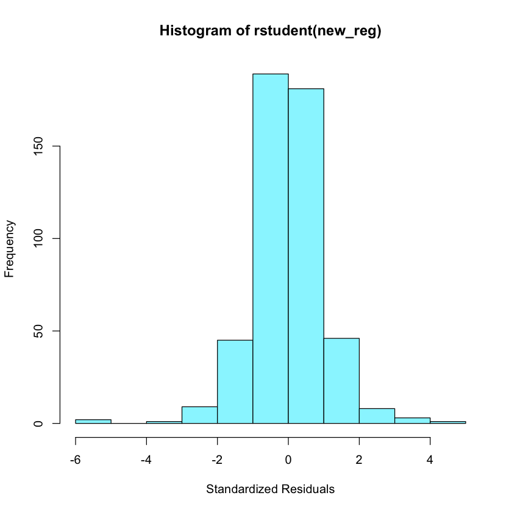

```r
hist(rstudent(new_reg), xlab = 'Standardized Residuals', col = "cadetblue1")
```

Тест Колмогорова-Смирнова для нормированных остатков

Ответ: Остатки не нормально распределенные

```r
ks.test(rstudent(new_reg), "pnorm", 0, 1)
```

```
	One-sample Kolmogorov-Smirnov test

data:  rstudent(new_reg)
D = 0.06687, p-value = 0.02614
alternative hypothesis: two-sided
```

```r
pearson.test(rstudent(new_reg))
```

```
	Pearson chi-square normality test

data:  rstudent(new_reg)
P = 40.971, p-value = 0.005653
```

Построение нормального квантиль-квантиль графика (QQ графика)

Если распределение с.в. нормальное, то график - прямая

На графике ниже концы не прямые -> есть тяжелые хвосты -> остатки п.н. не нормально

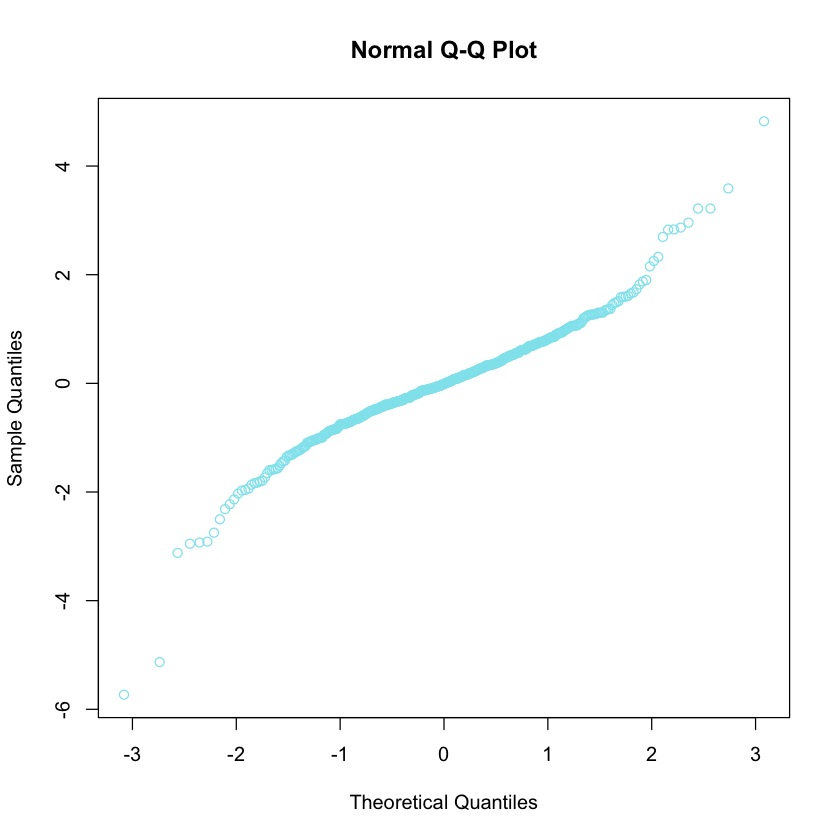

```r
qqnorm(rstudent(new_reg),col = "cadetblue2")
```

Построение автокорреляционной полосы

Ответ: Почти все автокорреляции лежат внутри полосы -> остатки некоррелируют, не зависимы

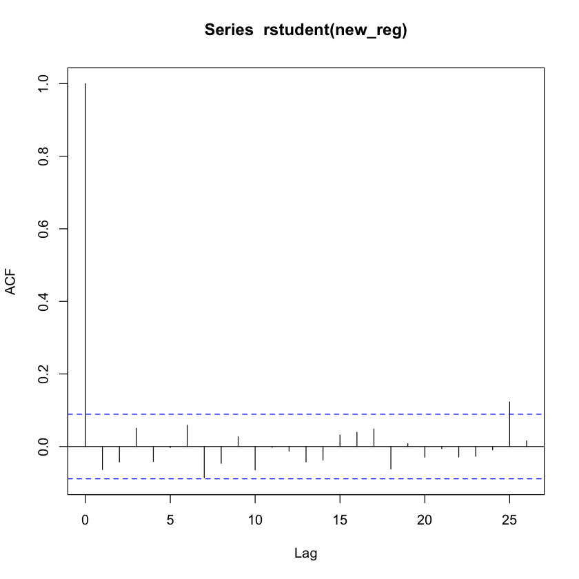

```r
acf(rstudent(new_reg))
```